# Effect of Severe Weather Events on Population Health and Economy

## Synopsis

Storms are a major cause of public health and economic concern. This report aims to explore which type of weather events are most harmful with respect to population health and with respect to economic consequences. It makes use of the U.S. National Oceanic and Atmospheric Administration’s storm database, which keeps track of major storms and weather events in the United States, such as when or where storms occur, as well as any estimates of financial and human costs accompanying storms and weather events.

### Loading and Processing the Raw Data

A dataset in the form of comma-separated-value file was obtained from the course website, which contains the U.S. National Oceanic and Atmospheric Administration’s storm database.

### Reading the storm data

```r
require(dplyr)
require(ggplot2)
require(utils)
setwd("/Users/edwardlau/Documents/Ping Lab/R Projects/coursera-data-science/Reproducible Research/Project 2/")

data <- read.csv("repdata-data-StormData.csv.bz2")
```

The following takes a glimpse of the data and report the dimension

```r
glimpse(data)
```

```
## Observations: 902297
## Variables:
## $ STATE__    (dbl) 1, 1, 1, 1, 1, 1, 1, 1, 1, 1, 1, 1, 1, 1, 1, 1, 1, ...
## $ BGN_DATE   (fctr) 4/18/1950 0:00:00, 4/18/1950 0:00:00, 2/20/1951 0:...
## $ BGN_TIME   (fctr) 0130, 0145, 1600, 0900, 1500, 2000, 0100, 0900, 20...
## $ TIME_ZONE  (fctr) CST, CST, CST, CST, CST, CST, CST, CST, CST, CST, ...
## $ COUNTY     (dbl) 97, 3, 57, 89, 43, 77, 9, 123, 125, 57, 43, 9, 73, ...
## $ COUNTYNAME (fctr) MOBILE, BALDWIN, FAYETTE, MADISON, CULLMAN, LAUDER...
## $ STATE      (fctr) AL, AL, AL, AL, AL, AL, AL, AL, AL, AL, AL, AL, AL...
## $ EVTYPE     (fctr) TORNADO, TORNADO, TORNADO, TORNADO, TORNADO, TORNA...
## $ BGN_RANGE  (dbl) 0, 0, 0, 0, 0, 0, 0, 0, 0, 0, 0, 0, 0, 0, 0, 0, 0, ...
## $ BGN_AZI    (fctr) , , , , , , , , , , , , , , , , , , , , , , , ,
## $ BGN_LOCATI (fctr) , , , , , , , , , , , , , , , , , , , , , , , ,
## $ END_DATE   (fctr) , , , , , , , , , , , , , , , , , , , , , , , ,
## $ END_TIME   (fctr) , , , , , , , , , , , , , , , , , , , , , , , ,
```

[output cut: 24 more lines]

```r
dim(data)
```

```
## [1] 902297     37
```

The columns are we interested in are EVTYPE (weather event type), INJURIES, FATALITIES, and PROPDMG (property damage).

## Results

### Public Health

Below summarizes the summed injuries and fatalities of each types of weather events over the years, including only those above a particular threshold of injuries/ fatalities caused. We are not concerned about missing values for the questions asked, since we are only interested in knowing which events are most harmful.

```r
summary <- data %>% group_by(EVTYPE) %>% summarize(INJ = sum(INJURIES), FAT = sum(FATALITIES)) %>% filter(INJ > 1000 | FAT > 100) %>% arrange(desc(FAT))
summary
```

```
## Source: local data frame [23 x 3]
##
##            EVTYPE   INJ  FAT
## 1         TORNADO 91346 5633
## 2  EXCESSIVE HEAT  6525 1903
## 3     FLASH FLOOD  1777  978
## 4            HEAT  2100  937
## 5       LIGHTNING  5230  816
## 6       TSTM WIND  6957  504
## 7           FLOOD  6789  470
## 8     RIP CURRENT   232  368
## 9       HIGH WIND  1137  248
## 10      AVALANCHE   170  224
## ..            ...   ...  ...
```

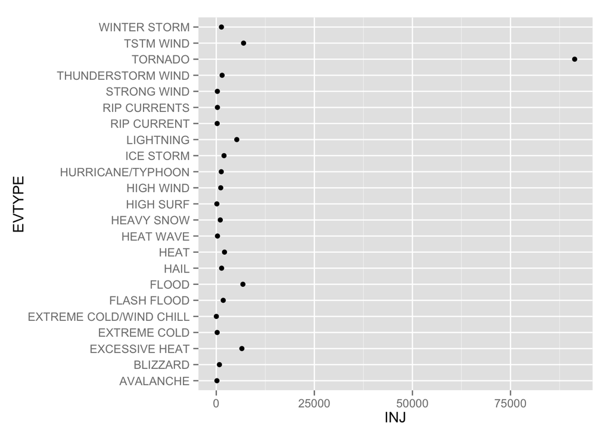

```r
qplot(INJ, EVTYPE, data=summary)
```

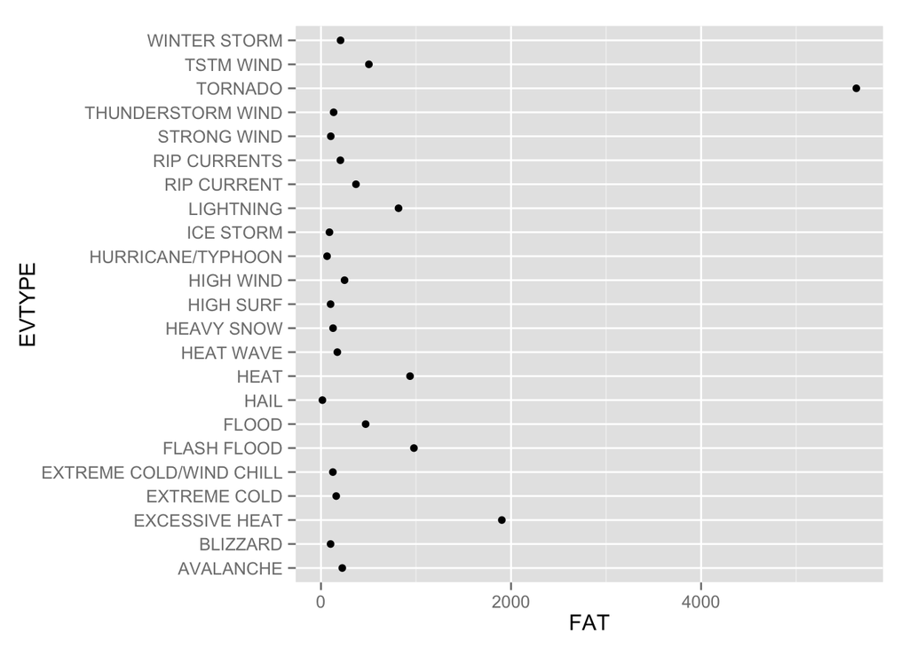

```r
qplot(FAT, EVTYPE, data=summary)
```

It can be seen that tornado is by far the most severe weather events with regard to public health.

### Economic consequences

Below summarizes the property damage of each types of weather events, including only those above a particular threshold of damage caused.

```r
summary2 <- data %>% group_by(EVTYPE) %>% summarize(PROP = sum(PROPDMG)) %>% filter(PROP > 10000) %>% arrange(desc(PROP))
summary2
```

```
## Source: local data frame [30 x 2]
##
##                EVTYPE      PROP
## 1             TORNADO 3212258.2
## 2         FLASH FLOOD 1420124.6
## 3           TSTM WIND 1335965.6
## 4               FLOOD  899938.5
## 5   THUNDERSTORM WIND  876844.2
## 6                HAIL  688693.4
## 7           LIGHTNING  603351.8
## 8  THUNDERSTORM WINDS  446293.2
## 9           HIGH WIND  324731.6
## 10       WINTER STORM  132720.6
## ..                ...       ...
```

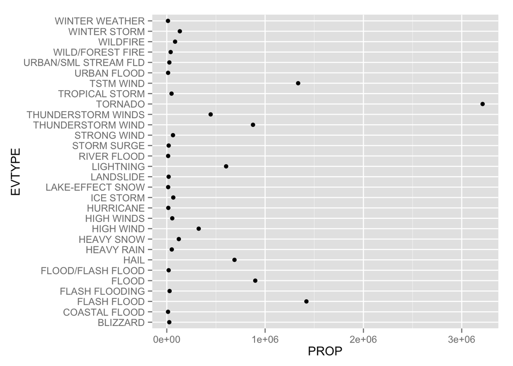

```r
qplot(PROP, EVTYPE, data=summary2)
```

It can be seen that tornado is by far the most severe weather events with regard to economic consequences.

## Conclusions

Tornados are a major cause of injuries and property damage. Measures that mitigate tornado-associated damage are likely to have high impact.